# HW3

Settings

```r
library(tidyverse)
library(tidytext)
library(ggplot2)
library(textdata)
library(knitr)
library(dplyr)
library(tidyr)
pubmed <- read_csv("pubmed.csv", show_col_types = FALSE)
```

Question 1

```r
# 1 Number of abstracts per search term
abstract_count <- pubmed %>%
  count(term, name = "num_abstracts")

kable(abstract_count, caption = "Number of abstracts per search term")
```

Number of abstracts per search term

| term | num_abstracts |
| --- | --- |
| covid | 981 |
| cystic fibrosis | 376 |
| meningitis | 317 |
| preeclampsia | 780 |
| prostate cancer | 787 |

```r
# 2 Tokenize abstracts and count tokens
tokens <- pubmed %>%
  unnest_tokens(word, abstract) %>%
  count(term, word, sort = TRUE)
# 3 5 most common tokens per search term
top_tokens <- tokens %>%
  group_by(term) %>%
  slice_max(n, n = 5)

kable(top_tokens, caption = "Top 5 most common tokens per search term")
```

Top 5 most common tokens per search term

| term | word | n |
| --- | --- | --- |
| covid | the | 9741 |
| covid | of | 7668 |
| covid | covid | 7275 |
| covid | 19 | 7035 |
| covid | and | 6861 |
| cystic fibrosis | the | 2677 |
| cystic fibrosis | of | 2304 |
| cystic fibrosis | and | 1777 |
| cystic fibrosis | in | 1497 |
| cystic fibrosis | to | 1011 |
| meningitis | the | 2489 |
| meningitis | of | 2269 |
| meningitis | and | 1683 |
| meningitis | in | 1322 |
| meningitis | a | 830 |
| preeclampsia | the | 7119 |
| preeclampsia | of | 6837 |
| preeclampsia | and | 5255 |
| preeclampsia | in | 3869 |
| preeclampsia | to | 2651 |
| prostate cancer | the | 6100 |
| prostate cancer | of | 5682 |
| prostate cancer | and | 4417 |
| prostate cancer | cancer | 3840 |
| prostate cancer | prostate | 3832 |

The number of abstracts associated with each search term is shown in table 1 The whole tokens dataset is too big to be shown, so I just say the conclusion, the interesting thing is that many of the words that have the most frequency is stop word, and some disease-specific terms also have large frequency in it. The 5 most common tokens for each search term is shown in the table 2.

Question 2

```r
# 1 Remove stop words
tokens_nostop <- tokens %>%
  anti_join(stop_words, by = "word")
# 2 5 most common tokens per search term after removing
top_tokens_nostop <- tokens_nostop %>%
  group_by(term) %>%
  slice_max(n, n = 5)

kable(top_tokens_nostop, caption = "Top 5 most common tokens per search term (without stop words)")
```

Top 5 most common tokens per search term (without stop words)

| term | word | n |
| --- | --- | --- |
| covid | covid | 7275 |
| covid | 19 | 7035 |
| covid | patients | 2293 |
| covid | disease | 943 |
| covid | pandemic | 800 |
| cystic fibrosis | fibrosis | 867 |
| cystic fibrosis | cystic | 862 |
| cystic fibrosis | cf | 625 |
| cystic fibrosis | patients | 586 |
| cystic fibrosis | disease | 400 |
| meningitis | patients | 446 |
| meningitis | meningitis | 429 |
| meningitis | meningeal | 219 |
| meningitis | csf | 206 |
| meningitis | clinical | 187 |
| preeclampsia | pre | 2038 |
| preeclampsia | eclampsia | 2005 |
| preeclampsia | preeclampsia | 1863 |
| preeclampsia | women | 1196 |
| preeclampsia | pregnancy | 969 |
| prostate cancer | cancer | 3840 |
| prostate cancer | prostate | 3832 |
| prostate cancer | patients | 934 |
| prostate cancer | treatment | 926 |
| prostate cancer | disease | 652 |

Question 3

```r
# 1 Tokenize into bigrams
bigrams <- pubmed %>%
  unnest_tokens(bigram, abstract, token = "ngrams", n = 2) %>%
  count(bigram, sort = TRUE)
# 2 Top 10 bigrams
top10_bigrams <- bigrams %>%
  slice_max(n, n = 10)

kable(top10_bigrams, caption = "Top 10 most common bigrams")
```

Top 10 most common bigrams

| bigram | n |
| --- | --- |
| covid 19 | 6969 |
| of the | 3883 |
| in the | 3418 |
| prostate cancer | 3222 |
| pre eclampsia | 1854 |
| patients with | 1587 |
| of covid | 1519 |
| and the | 1154 |
| to the | 1061 |
| of prostate | 870 |

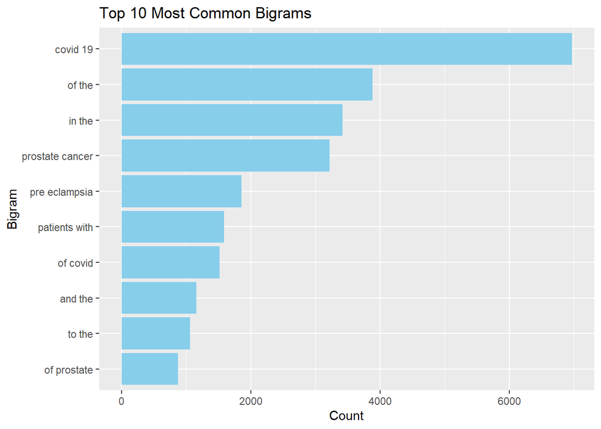

```r
# 3 Visualization of bigrams
ggplot(top10_bigrams, aes(x = reorder(bigram, n), y = n)) +
  geom_col(fill = "skyblue") +
  coord_flip() +
  labs(title = "Top 10 Most Common Bigrams", x = "Bigram", y = "Count")
```

The 10 most common bigrams is shown in the table, the covid 19 have the most frequency in bigrams

Question 4

```r
# 1 TF-IDF for each word-search term combination
tfidf_words <- tokens_nostop %>%
  bind_tf_idf(word, term, n) %>%
  group_by(term) %>%
  slice_max(tf_idf, n = 5) %>%
  arrange(term, desc(tf_idf))

kable(tfidf_words %>% select(term, word, tf_idf),
      caption = "Top 5 tokens per search term by TF-IDF")
```

Top 5 tokens per search term by TF-IDF

| term | word | tf_idf |
| --- | --- | --- |
| covid | covid | 0.1041122 |
| covid | pandemic | 0.0114488 |
| covid | coronavirus | 0.0092592 |
| covid | sars | 0.0053237 |
| covid | cov | 0.0047799 |
| cystic fibrosis | cf | 0.0214528 |
| cystic fibrosis | fibrosis | 0.0165906 |
| cystic fibrosis | cystic | 0.0164949 |
| cystic fibrosis | cftr | 0.0051849 |
| cystic fibrosis | sweat | 0.0050041 |
| meningitis | meningitis | 0.0263852 |
| meningitis | meningeal | 0.0134694 |
| meningitis | pachymeningitis | 0.0091641 |
| meningitis | csf | 0.0072132 |
| meningitis | meninges | 0.0065194 |
| preeclampsia | eclampsia | 0.0410869 |
| preeclampsia | preeclampsia | 0.0381770 |
| preeclampsia | pregnancy | 0.0063025 |
| preeclampsia | maternal | 0.0051838 |
| preeclampsia | gestational | 0.0039140 |
| prostate cancer | prostate | 0.0906020 |
| prostate cancer | androgen | 0.0072113 |
| prostate cancer | psa | 0.0066675 |
| prostate cancer | prostatectomy | 0.0050834 |
| prostate cancer | castration | 0.0034992 |

Question 5

```r
# 1 Sentiment Analysis using NRC lexicon
nrc <- get_sentiments("nrc")

sentiment_nrc <- tokens_nostop %>%
  inner_join(nrc, by = "word", relationship = "many-to-many")
# 2 Most common sentiment per search term
common_sentiment <- sentiment_nrc %>%
  count(term, sentiment, sort = TRUE) %>%
  group_by(term) %>%
  slice_max(n, n = 1)

kable(common_sentiment, caption = "Most common sentiment per search term (including positive/negative)")
```

Most common sentiment per search term (including positive/negative)

| term | sentiment | n |
| --- | --- | --- |
| covid | positive | 623 |
| cystic fibrosis | positive | 392 |
| meningitis | positive | 296 |
| preeclampsia | positive | 466 |
| prostate cancer | positive | 513 |

```r
# 3 Exclude "positive" and "negative"
common_sentiment_no_posneg <- sentiment_nrc %>%
  filter(!sentiment %in% c("positive", "negative")) %>%
  count(term, sentiment, sort = TRUE) %>%
  group_by(term) %>%
  slice_max(n, n = 1)

kable(common_sentiment_no_posneg, caption = "Most common sentiment per search term (excluding positive/negative)")
```

Most common sentiment per search term (excluding positive/negative)

| term | sentiment | n |
| --- | --- | --- |
| covid | trust | 352 |
| cystic fibrosis | trust | 211 |
| meningitis | fear | 161 |
| preeclampsia | trust | 255 |
| prostate cancer | trust | 281 |

The most common sentiment for each search term is shown in table 1. And the result after removing “positive” and “negative” from the list is shown in table 2

Question 6

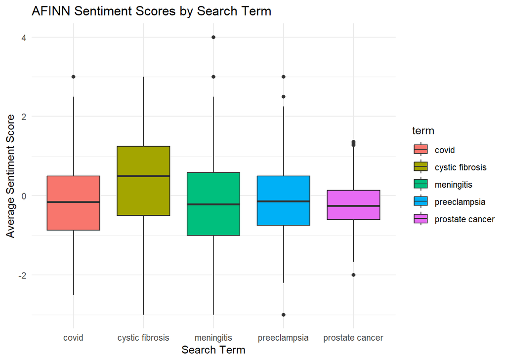

```r
# 1 Sentiment Analysis using AFINN lexicon
afinn <- get_sentiments("afinn")

afinn_scores <- pubmed %>%
  mutate(id = row_number()) %>%
  unnest_tokens(word, abstract) %>%
  inner_join(afinn, by = "word") %>%
  group_by(term, id) %>%
  summarize(mean_score = mean(value), .groups = "drop")

# 2 Visualization of average positivity scores
ggplot(afinn_scores, aes(x = term, y = mean_score, fill = term)) +
  geom_boxplot() +
  labs(title = "AFINN Sentiment Scores by Search Term",
       x = "Search Term", y = "Average Sentiment Score") +
  theme_minimal()
```